# Student_performance

Buthaina Alshareef

21-10-2020

```
## [1] "gender"                      "race.ethnicity"
## [3] "parental.level.of.education" "lunch"
## [5] "test.preparation.course"     "math.score"
## [7] "reading.score"               "writing.score"
```

# Descriptive Statistics

### Math Score

[output not shown]

### Reading Score

[output not shown]

### Writing Score

[output not shown]

## Inferential statistics

#### Normal Distribution

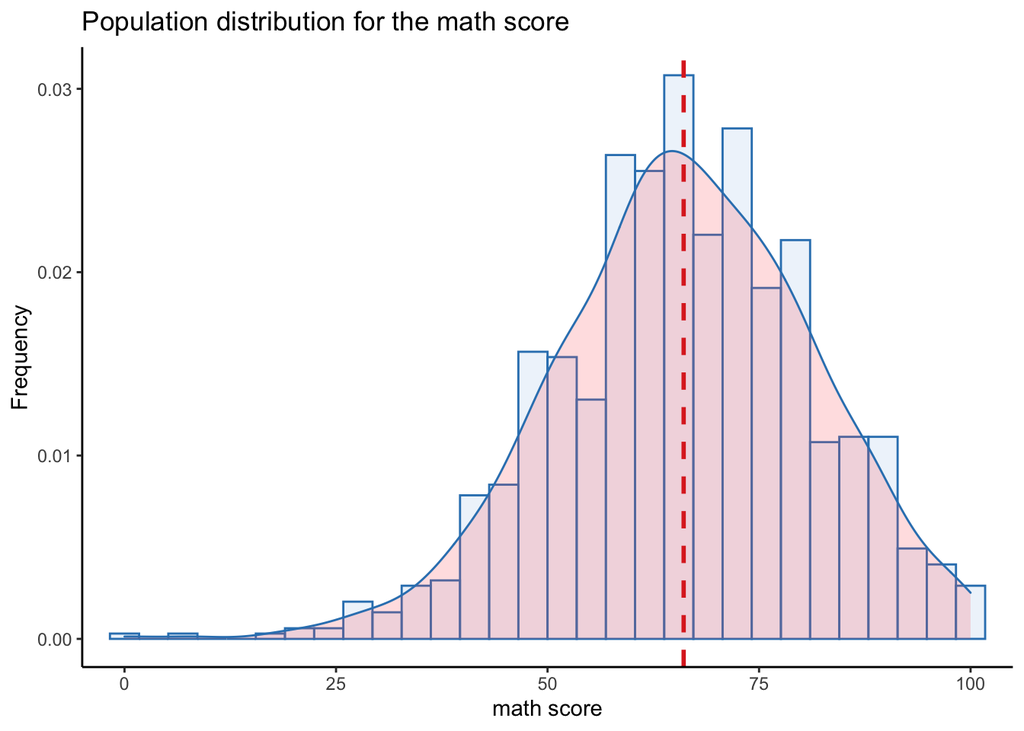

### Sample means for Math Score

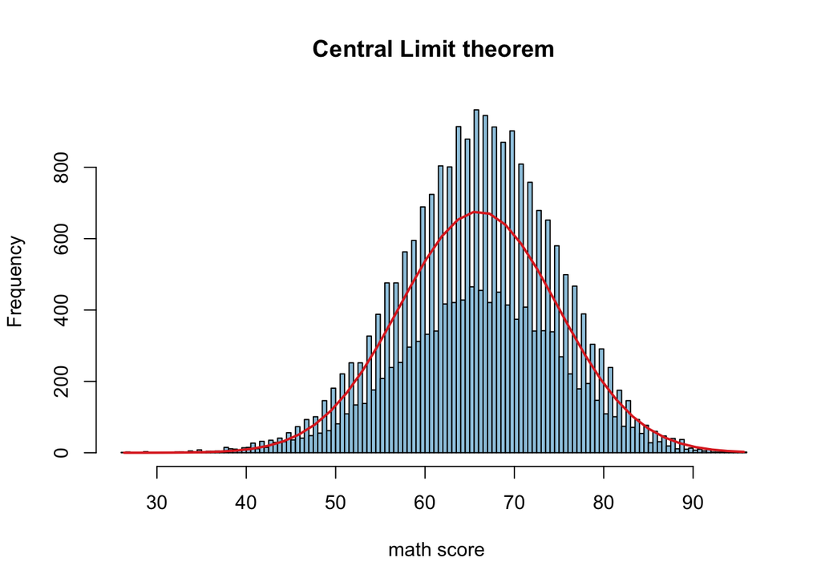

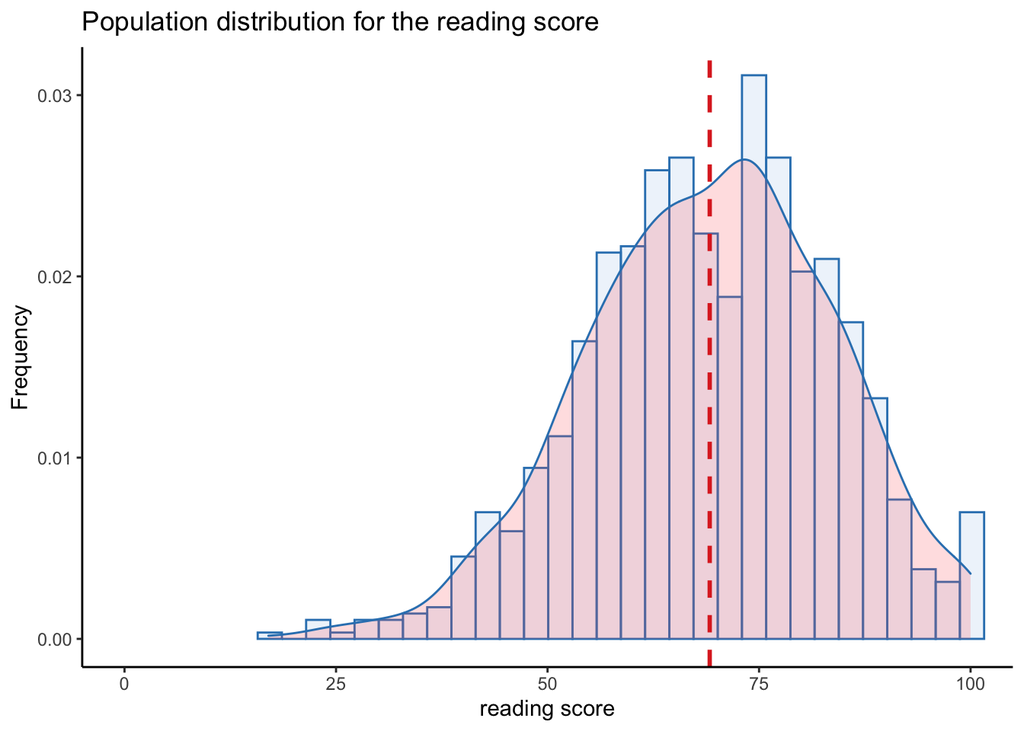

### Sample means for Reading Score

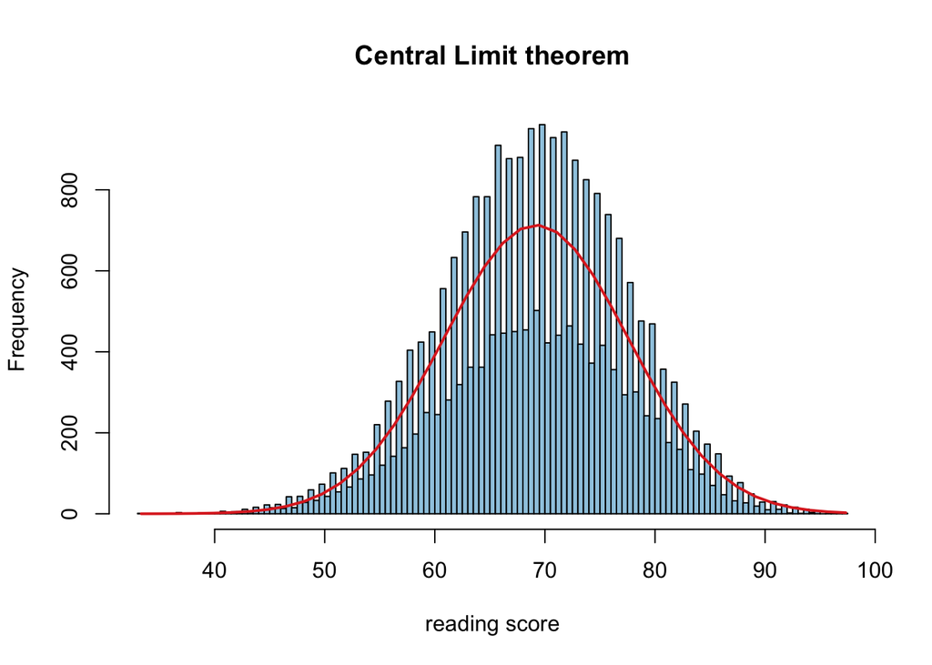

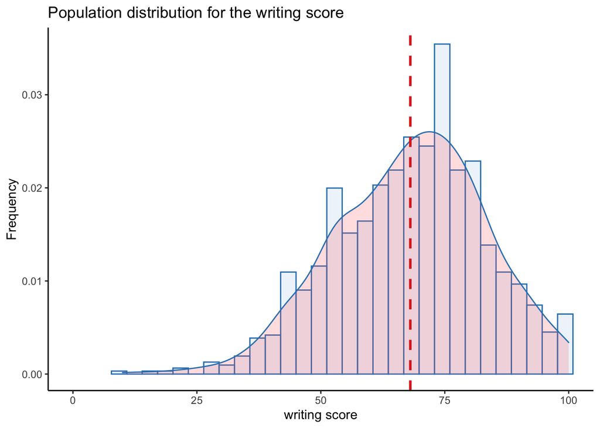

### Sample means for Writing Score

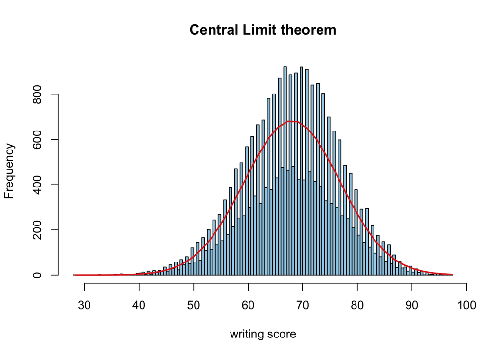

- The data is normally distributed in math, reading, and writing score in both population and sample means
- the sample mean $\bar{x}$ is an unbiased estimator for the underlying population mean $\mu$
- the sample means $\bar{x}$ are centered on the population mean $\mu$

# 95% CI

Math score

```
##
##  One Sample t-test
##
## data:  student$math.score
## t = 0, df = 999, p-value = 1
## alternative hypothesis: true mean is not equal to 66.089
## 95 percent confidence interval:
##  65.14806 67.02994
## sample estimates:
## mean of x
##    66.089
```

There is a 95% chance that interval [65.14806, 67.02994] *covers* the true population parameter $\mu$ (66.089).

```
##
##  One Sample t-test
##
## data:  student$reading.score
## t = 0, df = 999, p-value = 1
## alternative hypothesis: true mean is not equal to 69.169
## 95 percent confidence interval:
##  68.26299 70.07501
## sample estimates:
## mean of x
##    69.169
```

There is a 95% chance that interval [68.26299, 70.07501] *covers* the true population parameter $\mu$ (69.169).

```
##
##  One Sample t-test
##
## data:  student$writing.score
## t = 0, df = 999, p-value = 1
## alternative hypothesis: true mean is not equal to 68.054
## 95 percent confidence interval:
##  67.11104 68.99696
## sample estimates:
## mean of x
##    68.054
```

There is a 95% chance that interval [67.11104, 68.99696] *covers* the true population parameter $\mu$ (68.054).

# Probability

The probability for the students to get more than 50 in math is 85%

The probability for the students to get more than 50 in writing is 87.6%

The probability for the students to get more than 50 in reading is 90.3%

# Two sample t-test

Is there a relationship between gender and scores in each subject?

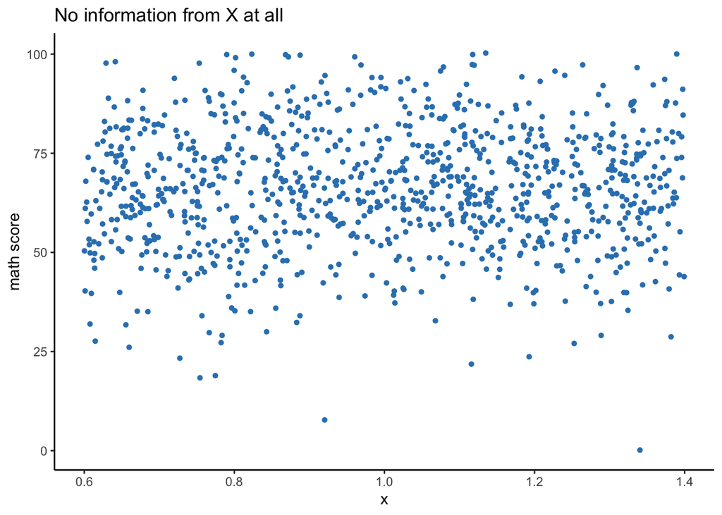

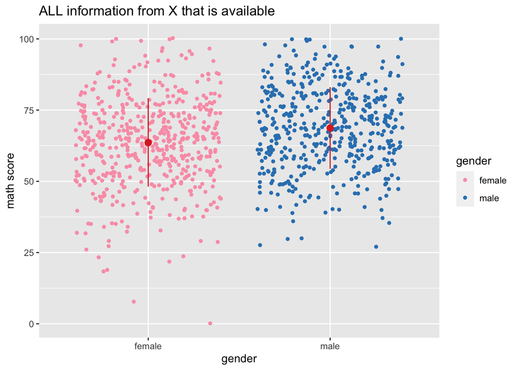

$\bar{x}_{female} - \bar{x}_{male}$

```
##
##  Welch Two Sample t-test
##
## data:  math.score by gender
## t = -5.398, df = 997.98, p-value = 8.421e-08
## alternative hypothesis: true difference in means is not equal to 0
## 95 percent confidence interval:
##  -6.947209 -3.242813
## sample estimates:
## mean in group female   mean in group male
##             63.63320             68.72822
```

Here the p-value = 8.421e-08 which means:

- Reject the null hypothesis
- There is evidence that the gender is related to the scores in math
- We can use the gender to predict scores in math!

# Linear regression

Is there a relationship between math score and scores in each subject?

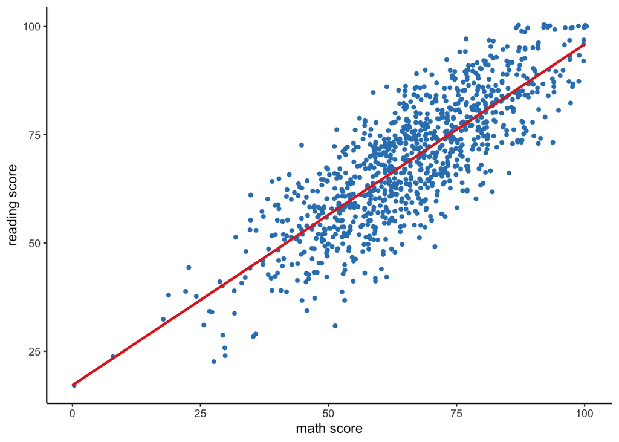

t-test

```
##
## Call:
## lm(formula = reading.score ~ math.score, data = student)
##
## Residuals:
##      Min       1Q   Median       3Q      Max
## -26.2905  -5.8011   0.1139   6.0341  21.4117
##
## Coefficients:
##             Estimate Std. Error t value Pr(>|t|)
## (Intercept) 17.14181    1.19000   14.40   <2e-16 ***
## math.score   0.78723    0.01755   44.85   <2e-16 ***
## ---
## Signif. codes:  0 '***' 0.001 '**' 0.01 '*' 0.05 '.' 0.1 ' ' 1
##
## Residual standard error: 8.411 on 998 degrees of freedom
## Multiple R-squared:  0.6684, Adjusted R-squared:  0.6681
## F-statistic:  2012 on 1 and 998 DF,  p-value: < 2.2e-16
```

Reject the null hypothesis There is a relashion between math score and reading score

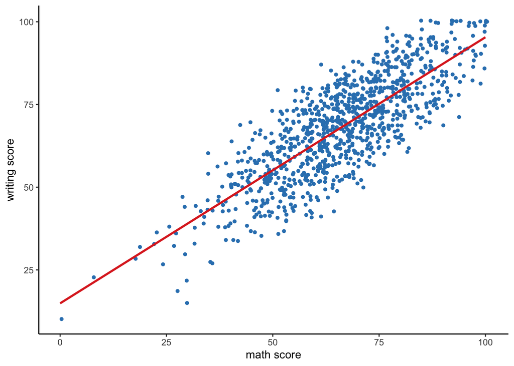

t-test

```
##
## Call:
## lm(formula = writing.score ~ math.score, data = student)
##
## Residuals:
##      Min       1Q   Median       3Q      Max
## -24.0252  -7.2435   0.4416   6.8220  23.0831
##
## Coefficients:
##             Estimate Std. Error t value Pr(>|t|)
## (Intercept) 14.89422    1.28294   11.61   <2e-16 ***
## math.score   0.80437    0.01892   42.51   <2e-16 ***
## ---
## Signif. codes:  0 '***' 0.001 '**' 0.01 '*' 0.05 '.' 0.1 ' ' 1
##
## Residual standard error: 9.068 on 998 degrees of freedom
## Multiple R-squared:  0.6442, Adjusted R-squared:  0.6439
## F-statistic:  1807 on 1 and 998 DF,  p-value: < 2.2e-16
```

Reject the null hypothesis

# One-way ANOVA

Visualizing the relashionship between each group of education

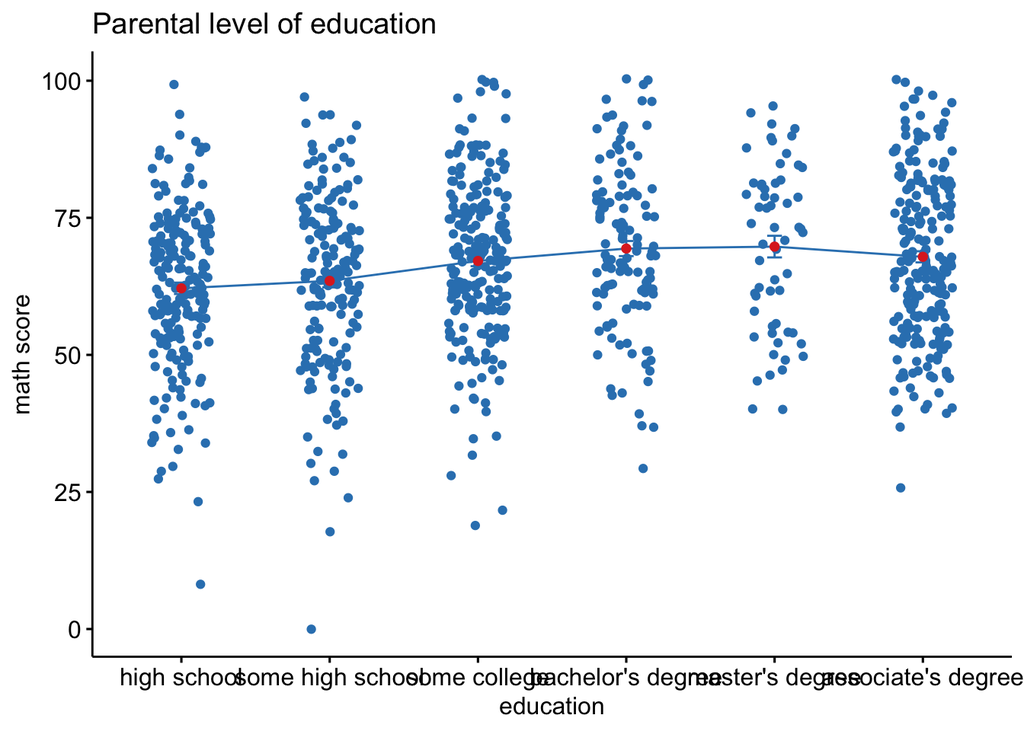

The lowest scores illustrates that the students whose parent have high school education

```
##                              Df Sum Sq Mean Sq F value   Pr(>F)
## parental.level.of.education   5   7296  1459.1   6.522 5.59e-06 ***
## Residuals                   994 222394   223.7
## ---
## Signif. codes:  0 '***' 0.001 '**' 0.01 '*' 0.05 '.' 0.1 ' ' 1
```

the low p-value indicates that the parental level of education means are different, thus the null hypothesis would be rejected.

[output not shown]

[output cut: 5 more lines]